# Лекция 2. Параметрический полиморфизм

ФП 2.0 · осень 2026

Андрей Стоян

осень 2026

## План на сегодня

- **Полиморфизм в языке**: System F, кайнды, полиморфизм первого класса, higher-kinded, GADT, структуры на уровне типов
- **Реализация**: сколько полиморфизм стоит во время исполнения
- **Полиморфизм по конвенции вызова**: boxed и unboxed, `TYPE`, representation polymorphism

## Где мы на карте

| Что сегодня | Где выстрелит |
| --- | --- |
| универсальная аппликация, кайнды | словари классов типов и семейства типов — глава 3 |
| higher-kinded полиморфизм | `Fix` и свёртки — глава 4; `Free` — глава 7 |
| типы высшего ранга | tagless final — глава 5; `ST`, хендлеры — главы 6–7 |
| GADT и структуры на уровне типов | типизированные интерпретаторы — глава 5; системы эффектов — глава 8 |
| стирание типов и словари | реализация классов типов — глава 3 |

## Параметрический полиморфизм в языке

## Что пропускает система типов

Корректность — семантическое свойство программы. По теореме Райса алгоритмически её границу не найти.

все программы

корректные

1 + 'a'

idInt 42

id 42, id 'x'

f g = (g 42, g 'a')

if True then 1 else 'a'

## Что пропускает система типов

Разрешимая система типов очерчивает область поменьше: вместе с некорректными программами она отвергает много корректных.

все программы

корректные

типизируются в λ→

1 + 'a'

idInt 42

id 42, id 'x'

f g = (g 42, g 'a')

if True then 1 else 'a'

## Что пропускает система типов

Параметрический полиморфизм расширяет область: один код единообразно работает с любыми типами.

все программы

корректные

+ полиморфизм

1 + 'a'

idInt 42

id 42, id 'x'

f g = (g 42, g 'a')

if True then 1 else 'a'

## Что пропускает система типов

Сегодня расширяем её дальше: ранги, higher-kinded, GADT, структуры на уровне типов. Граница всё равно останется внутри зелёной.

все программы

корректные

+ ранги, HKT, GADT, типы-индексы

1 + 'a'

idInt 42

id 42, id 'x'

f g = (g 42, g 'a')

if True then 1 else 'a'

## Скрытый аргумент

Один `id` — три места вызова. Кто и когда выбирает конкретный тип вместо `a`?

id x = x

id 42

id 'x'

id True

## Скрытый аргумент

Вызывающий код, в каждом месте свой: у `id` есть ещё один, скрытый аргумент — сам тип.

id x = x

id @Int 42

id @Char 'x'

id @Bool True

## Скрытый аргумент

И в определении его можно принять явно: функция двух аргументов — типа и значения.

id @a (x :: a) = x

id @Int 42

id @Char 'x'

id @Bool True

## Тип — такой же аргумент

System F: $\Lambda\alpha$ обобщает выражение по типу, аппликация к типу его подставляет. Получается редекс, как у обычной функции.

(Λα. λx:α. x) nat 42

@

@

42

Λα

nat

λx:α

x

## Тип — такой же аргумент

Тип подставлен в аннотацию параметра: $\alpha \mapsto \mathrm{nat}$. Осталась обычная функция и обычный β-редекс.

(λx:nat. x) 42

@

λx:nat

42

x

## Тип — такой же аргумент

Вызов `id @Int 42` в Haskell — те же два шага: сначала выбран тип, потом передано значение.

42

42

## Одна и та же пара правил — для значений и для типов

**Обобщаем по значению**: λ добавляет стрелку, аппликация снимает

$$\dfrac{x : \tau,\ \Gamma \vdash M : \sigma}{\Gamma \vdash \lambda x : \tau.\,M : \tau \to \sigma}\ {\scriptstyle Lam}$$

$$\dfrac{\Gamma \vdash M : \tau \to \sigma \quad \Gamma \vdash N : \tau}{\Gamma \vdash M\ N : \sigma}\ {\scriptstyle App}$$

**Обобщаем по типу**: Λ добавляет $\forall$, аппликация к типу снимает

$$\dfrac{\alpha,\ \Gamma \vdash M : \tau}{\Gamma \vdash \Lambda\alpha.\,M : \forall\alpha.\,\tau}\ {\scriptstyle TLam}$$

$$\dfrac{\Gamma \vdash M : \forall\alpha.\,\tau}{\Gamma \vdash M\ \sigma : [\alpha \mapsto \sigma]\ \tau}\ {\scriptstyle TApp}$$

## Дерево вывода: `id` получает тип, потом значение

$\mathbf{id} = \Lambda\alpha.\,\lambda x : \alpha.\,x$, тип $\mathbf{id} : \forall\alpha.\,\alpha\to\alpha$

$\vdash \mathbf{id} : \forall\alpha.\,\alpha\to\alpha$ def

$\vdash \mathbf{id}\ \mathrm{nat} : \mathrm{nat}\to\mathrm{nat}$ TApp

$\vdash 42 : \mathrm{nat}$ const

$\vdash \mathbf{id}\ \mathrm{nat}\ 42 : \mathrm{nat}$ App

шаги

1. App: аппликация — две посылки

2. TApp: снимаем ∀, α ↦ nat; const: 42

3. def: тип id по определению

## Когда типы приходится писать руками

```haskell
ghci> read "42"                  -- какой тип результата? из терма не вывести
*** Exception: Prelude.read: no parse

ghci> read @Int "42"
42

ghci> read @Double "42"
42.0
```

Какой тип у выражения `const @Int`? А у `const @Int @Char`? От чего зависит порядок, в котором передаются типы?

```haskell
const @Int       :: Int -> b -> Int
const @Int @Char :: Int -> Char -> Int
```

Порядок — порядок первого появления типовых переменных в сигнатуре слева направо; явный `forall b a .` его меняет.

## Типы тоже вычисляются

```haskell
type Pair a b = forall c . (a -> b -> c) -> c    -- пара по Чёрчу

pair :: a -> b -> Pair a b
pair x y = \f -> f x y

fst :: Pair a b -> a
fst p = p (\x _ -> x)
```

```haskell
ghci> :kind! Pair Int Int
= forall c. (Int -> Int -> c) -> c        -- синоним — функция на типах: вычислился

ghci> :kind! Maybe Int
= Maybe Int                               -- конструктор номинативен: вычислять нечего
```

## λ-исчисление на уровне типов

Синоним с параметрами — абстракция, только на типах

$$\mathbf{Pair} = \lambda \tau\,\sigma.\,\forall \gamma.\,(\tau \to \sigma \to \gamma) \to \gamma$$

Применение абстракции к типу редуцируется подстановкой, как на уровне термов

$$(\lambda\alpha.\,\tau)\ \sigma \ \rightsquigarrow\ [\alpha \mapsto \sigma]\ \tau$$

## Редукция Pair Int Int

Что произошло в GHCi? Применение синонима к аргументам — выражение на уровне типов, и его можно вычислять.

Pair Int Int

## Редукция Pair Int Int

Раскрываем имя $\mathbf{Pair}$: получаем аппликацию типовой абстракции к двум аргументам — редекс на уровне типов.

(λτ σ. ∀γ. (τ → σ → γ) → γ) Int Int

## Редукция Pair Int Int

Первый β-шаг на уровне типов: $\tau \mapsto \mathrm{Int}$; остался редекс с $\sigma$.

(λσ. ∀γ. (Int → σ → γ) → γ) Int

## Редукция Pair Int Int

Второй β-шаг: $\sigma \mapsto \mathrm{Int}$. Нормальная форма — полиморфный тип, у которого квантор остался внутри: пара — функция, ждущая продолжение.

∀γ. (Int → Int → γ) → γ

## Раз типы применяют к типам — их можно применить неправильно

```haskell
ghci> :kind Maybe Maybe
error: Expecting one more argument to ‘Maybe’
       Expected a type, but ‘Maybe’ has kind ‘* -> *’

ghci> :kind Int Bool
error: Expected kind ‘* -> k’, but ‘Int’ has kind ‘*’
```

- Δ **Кайнды** — система типов для типов: следит, чтобы вычисления на типах были осмысленными и завершались

## Три этажа типизации: Just True

Этаж термов: вершинам дерева терма `Just True` приписаны типы — пока как записи.

Just True

@

Just

True

$: \mathrm{Maybe}\ \mathrm{Bool}$

$: \mathrm{Bool} \to \mathrm{Maybe}\ \mathrm{Bool}$

$: \mathrm{Bool}$

## Три этажа типизации: Just True

Но тип — тоже дерево: у `Just` это стрелка с поддеревьями `Bool` и аппликацией `Maybe` к `Bool`; у `True` — дерево из одного листа.

Just True

@

Just

True

$: \mathrm{Maybe}\ \mathrm{Bool}$

$:$

$:$

→

Bool

@

Maybe

Bool

Bool

## Три этажа типизации: Just True

Этаж типов: теперь уже вершинам деревьев типов приписаны кайнды. Аппликация типа к типу снимает стрелку в кайнде, как аппликация терма снимает стрелку в типе.

Just True

@

Just

True

$: \mathrm{Maybe}\ \mathrm{Bool}$

$:$

$:$

→

Bool

@

Maybe

Bool

Bool

$: \mathrm{Type}$

$: \mathrm{Type}$

$: \mathrm{Type}$

$: \mathrm{Type} \to \mathrm{Type}$

$: \mathrm{Type}$

$: \mathrm{Type}$

## Три этажа типизации: Just True

И кайнды — тоже деревья: `Type -> Type` у `Maybe` — стрелка из двух листьев `Type`, остальные — деревья из одного листа. Что приписывается их вершинам — в конце раздела.

Just True

@

Just

True

$: \mathrm{Maybe}\ \mathrm{Bool}$

$:$

$:$

→

Bool

@

Maybe

Bool

Bool

$: \mathrm{Type}$

$: \mathrm{Type}$

$: \mathrm{Type}$

$:$

$: \mathrm{Type}$

$: \mathrm{Type}$

→

Type

Type

## Правила кайндизации: те же правила, этажом выше

**λ-исчисление на типах**

$$\dfrac{\alpha : \kappa_1,\ \Gamma \vdash \tau : \kappa_2}{\Gamma \vdash \lambda\alpha : \kappa_1.\,\tau : \kappa_1 \to \kappa_2}\ {\scriptstyle KLam}$$

$$\dfrac{\Gamma \vdash \tau : \kappa_1 \to \kappa_2 \quad \Gamma \vdash \sigma : \kappa_1}{\Gamma \vdash \tau\ \sigma : \kappa_2}\ {\scriptstyle KApp}$$

**Конструкции обычных типов**

$$\dfrac{\Gamma \vdash \tau : * \quad \Gamma \vdash \sigma : *}{\Gamma \vdash \tau \to \sigma : *}\ {\scriptstyle KArrow}$$

$$\dfrac{\alpha : \kappa,\ \Gamma \vdash \tau : *}{\Gamma \vdash \forall\alpha : \kappa.\,\tau : *}\ {\scriptstyle KAll}$$

## Пара Чёрча в исчислении

$$\begin{array}{l}
\mathbf{Pair} : * \to * \to * \\
\mathbf{Pair} = \lambda \tau^*\,\sigma^*.\,\forall \gamma.\,(\tau \to \sigma \to \gamma) \to \gamma \\[0.4em]
\mathbf{pair} : \forall \alpha\,\beta.\,\alpha \to \beta \to \mathbf{Pair}\ \alpha\ \beta \\
\mathbf{pair} = \Lambda \alpha^*\,\beta^*.\,\lambda x^\alpha\,y^\beta.\,(\Lambda \gamma^*.\,\lambda f^{\alpha \to \beta \to \gamma}.\,f\ x\ y) \\[0.4em]
\mathbf{fst} : \forall \alpha\,\beta.\,\mathbf{Pair}\ \alpha\ \beta \to \alpha \\
\mathbf{fst} = \Lambda \alpha^*\,\beta^*.\,\lambda p^{\mathbf{Pair}\ \alpha\ \beta}.\,p\ \alpha\ (\mathbf{K}\ \alpha\ \beta)
\end{array}$$

## fst в действии

Достанем первую компоненту пары. Типы здесь — такие же аргументы, как значения.

fst nat bool (pair nat bool 1 true)

## fst в действии

Раскрыли $\mathbf{fst}$ и передали типы компонент: $\alpha \mapsto \mathrm{nat}$, $\beta \mapsto \mathrm{bool}$.

(λp. p nat (K nat bool)) (pair nat bool 1 true)

## fst в действии

Пара подставлена вместо $p$. Дальше она ждёт тип результата и функцию.

(pair nat bool 1 true) nat (K nat bool)

## fst в действии

Раскрыли $\mathbf{pair}$: внутри полиморфная функция, и первым она принимает тип результата $\gamma$.

(Λγ. λf. f 1 true) nat (K nat bool)

## fst в действии

$\gamma \mapsto \mathrm{nat}$: пара узнала, что из неё хотят достать число.

(λf. f 1 true) (K nat bool)

## fst в действии

Функция-выборщик получила обе компоненты.

K nat bool 1 true

## fst в действии

$\mathbf{K}$ вернула первую. Каждый квантор в типах $\mathbf{fst}$ и $\mathbf{Pair}$ — это шаг, на котором кто-то выбрал тип.

1

## Задачи: кайнды и пары

Постройте по правилам кайндизации дерево вывода $\mathbf{Pair} : * \to * \to *$. Какие правила и в каком порядке в нём применяются? Поредуцируйте тип $\mathbf{Pair}\ \mathrm{nat}\ \mathrm{bool}$ до нормальной формы.

Реализуйте на Haskell функции `snd` и `swap :: Pair a b -> Pair b a`. Запишите `snd` в исчислении с явными типовыми абстракциями и аппликациями.

Дерево вывода — на следующем слайде. Редукция — два β-шага, как у $\mathbf{Pair}\ \mathrm{Int}\ \mathrm{Int}$: нормальная форма $\forall\gamma.\,(\mathrm{nat}\to\mathrm{bool}\to\gamma)\to\gamma$.

```haskell
snd :: Pair a b -> b
snd p = p (\_ y -> y)

swap :: Pair a b -> Pair b a
swap p = \f -> p (\x y -> f y x)     -- или pair (snd p) (fst p)
```

$\mathbf{snd} = \Lambda \alpha^*\,\beta^*.\,\lambda p^{\mathbf{Pair}\ \alpha\ \beta}.\,p\ \beta\ (\mathbf{K}_*\ \alpha\ \beta)$

## Дерево вывода: кайнд `Pair`

$\Gamma = \tau : *,\ \sigma : *,\ \gamma : *$

$\Gamma \vdash \tau : *$ ctx

$\Gamma \vdash \sigma : *$ ctx

$\Gamma \vdash \gamma : *$ ctx

$\Gamma \vdash \sigma\to\gamma : *$ KArrow

$\Gamma \vdash \tau\to\sigma\to\gamma : *$ KArrow

$\Gamma \vdash \gamma : *$ ctx

$\Gamma \vdash (\tau\to\sigma\to\gamma)\to\gamma : *$ KArrow

$\tau : *,\ \sigma : * \vdash \forall\gamma.\,(\tau\to\sigma\to\gamma)\to\gamma : *$ KAll

$\tau : * \vdash \lambda\sigma.\,\forall\gamma.\,(\tau\to\sigma\to\gamma)\to\gamma : *\to*$ KLam

$\vdash \lambda\tau\,\sigma.\,\forall\gamma.\,(\tau\to\sigma\to\gamma)\to\gamma : *\to*\to*$ KLam

шаги

1. KLam: снимаем λτ

2. KLam: снимаем λσ

3. KAll: снимаем ∀γ

4. KArrow: внешняя стрелка

5. KArrow: τ → (σ → γ); ctx: γ

6. ctx: τ; KArrow: σ → γ

7. ctx: σ и γ

## First-class polymorphism

## Вывод типов спотыкается

Программа корректна: передай в неё `id` — получишь пару. Выведем её тип, как это делает алгоритм Хиндли–Милнера.

λg. (g 42, g 'a')

λg

(,)

@

@

g

42

g

'a'

## Вывод типов спотыкается

Аргументу функции алгоритм приписывает **один** тип $\gamma$, без кванторов внутри.

λg. (g 42, g 'a')

λg

(,)

@

@

g

42

g

'a'

$g : \gamma$

## Вывод типов спотыкается

Первое применение: $g$ применяют к числу, значит $\gamma = \mathrm{Int}\to\beta_1$.

λg. (g 42, g 'a')

λg

(,)

@

@

g

42

g

'a'

$g : \gamma$

$\gamma = \mathrm{Int}\to\beta_1$

## Вывод типов спотыкается

Второе: $\gamma = \mathrm{Char}\to\beta_2$. Но $\gamma$ уже занята, а $\mathrm{Int} \neq \mathrm{Char}$ — корректная программа отвергнута.

λg. (g 42, g 'a')

λg

(,)

@

@

g

42

g

'a'

$g : \gamma$

$\gamma = \mathrm{Int}\to\beta_1$

$\gamma = \mathrm{Char}\to\beta_2$

## Вывод типов спотыкается

Лекарство — квантор **слева от стрелки**: тип для $g$ выбирает сама функция, в каждом месте свой. Это тип высшего ранга.

λg. (g 42, g 'a')

λg

(,)

@

@

g

42

g

'a'

$g : \forall a.\,a \to a$

$g\ \mathrm{Int} : \mathrm{Int}\to\mathrm{Int}$

$g\ \mathrm{Char} : \mathrm{Char}\to\mathrm{Char}$

## Типы высшего ранга в Haskell

```haskell
f :: (forall a . a -> a) -> (Int, Char)        -- RankNTypes
f g = (g @Int 42, g @Char 'a')
```

```haskell
ghci> f (\x -> x)
(42,'a')
```

- − Цена: типы высшего ранга не выводятся — их приписывают руками, остальное выводится как раньше

Какую ошибку выдаст GHC, если убрать у `f` сигнатуру и типовые аппликации? Какой тип для `g` он пытался вывести?

Какой ранг имеет тип `Int -> (forall a . a -> a)`?

`Couldn't match expected type ‘Int’ with actual type ‘Char’`: первое применение зафиксировало `g :: Int -> b`. Про ранг — на следующем слайде.

## Ранг: где стоит квантор

Тип — дерево. Ранг считает, сколько раз по пути к квантору мы свернули **налево** от стрелки. Здесь один раз: ранг 2.

(∀a. a → a) → (Int, Char)

→

∀a

→

a

a

(Int, Char)

## Ранг: где стоит квантор

А в этом типе квантор стоит **справа** от стрелки…

Int → (∀a. a → a)

→

Int

∀a

→

a

a

## Ранг: где стоит квантор

…и его можно вынести наружу, ничего не изменив. Поворотов налево нет: ранг 1.

∀a. Int → a → a

∀a

→

Int

→

a

a

## Числа Чёрча и обёртки

```haskell
suc :: (forall a . (a -> a) -> a -> a) -> (b -> b) -> b -> b   -- ранг 2
suc n s z = s (n s z)
```

```haskell
newtype Church = Church (forall a . (a -> a) -> a -> a)        -- квантор под конструктором
(+) :: Church -> Church -> Church                              -- ранг 1
```

## Та же обёртка на Kotlin

```kotlin
interface Church {
    fun <a> fold(s: (a) -> a, z: a): a          // полиморфный метод: квантор под интерфейсом
}

fun plus(n: Church, m: Church): Church = object : Church {
    override fun <a> fold(s: (a) -> a, z: a): a = n.fold(s, m.fold(s, z))
}
```

## Импредикативное применение

Оператор `$` — обычная функция. Чему равна типовая переменная $a$ в выражении `runST $ do …`?

($) :: (a → b) → a → b

runST :: (∀s. ST s c) → c

## Импредикативное применение

$a$ специализируется на **полиморфный** тип. По умолчанию так нельзя; для `$` в GHC сделано исключение, для остальных функций — ImpredicativeTypes.

($) :: ((∀s. ST s c) → c) → (∀s. ST s c) → c

runST :: (∀s. ST s c) → c

## ST-trick: мутабельные ячейки в ограниченной области

```haskell
runST :: (forall s. ST s a) -> a

sumTo :: Int -> Int
sumTo n = runST do
  ref <- newSTRef 0
  forM [0..n] \i -> modifySTRef ref (+ i)
  readSTRef ref
```

```haskell
newSTRef :: v -> ST s (STRef s v)

ghci> runST (newSTRef True)                   -- попробуем вынести ссылку наружу
error: Couldn't match type ‘a’ with ‘STRef s Bool’
       because type variable ‘s’ would escape its scope
```

## s не может сбежать

Квантор по $s$ стоит слева от стрелки: его область действия — только аргумент `runST`.

runST :: (∀s. ST s a) → a

## s не может сбежать

Вернуть ссылку — значит взять $a = \mathrm{STRef}\ s\ \mathrm{Bool}$. Но тогда $s$ в результате оказывается **вне** области квантора: такого типа не существует.

runST :: (∀s. ST s (STRef s Bool)) → STRef s Bool

## Higher-kinded polymorphism

## Абстракция по контейнеру

Один `fmap` для списков, `Maybe` и деревьев: переменная $f$ стоит на месте **конструктора типов**.

fmap :: (a → b) → f a → f b

f :: Type → Type

## Абстракция по контейнеру

Подставляем список…

fmap :: (a → b) → [] a → [] b

[] :: Type → Type

## Абстракция по контейнеру

…`Maybe`…

fmap :: (a → b) → Maybe a → Maybe b

Maybe :: Type → Type

## Абстракция по контейнеру

…или дерево. В Haskell абстрагироваться можно по типам любых кайндов — и в функциях, и в `data`.

fmap :: (a → b) → Tree a → Tree b

Tree :: Type → Type

## Параметр — конструктор типов

```haskell
newtype Fix f = Fix (f (Fix f))                 -- Fix :: (Type -> Type) -> Type
cata :: forall (f :: Type -> Type) a . Functor f => (f a -> a) -> Fix f -> a
```

Какой кайнд у `Fix Maybe`? Приведите несколько значений этого типа. Какой знакомый тип они напоминают?

`Fix Maybe :: Type`; значения — `Fix Nothing`, `Fix (Just (Fix Nothing))`, `Fix (Just (Fix (Just (Fix Nothing))))`, … — натуральные числа Пеано.

## GADTs

## Некорректная программа — корректное значение

`data Expr = Const Int | IsZero Expr | If Expr Expr Expr`. Типу `Expr` всё равно, что внутри: каждый узел — `Expr`, значение Haskell корректно. А программа бессмысленна.

IsZero (IsZero (Const 1))

IsZero

IsZero

Const

1

$: \mathrm{Expr}$

$: \mathrm{Expr}$

$: \mathrm{Expr}$

## Некорректная программа — корректное значение

Добавим типу индекс — тип, в который выражение вычисляется. Теперь `IsZero` ждёт число, а получает булево: ошибка видна в типах.

IsZero (IsZero (Const 1))

IsZero

IsZero

Const

1

ждёт $\mathrm{Expr}\ \mathrm{Int}$

$: \mathrm{Expr}\ \mathrm{Bool}$

$: \mathrm{Expr}\ \mathrm{Int}$

## Обобщённые алгебраические типы данных

```haskell
data Expr ty where                       -- data через типы конструкторов
  Const :: Int -> Expr Int
  IsZero :: Expr Int -> Expr Bool
  If :: forall ty . Expr Bool -> Expr ty -> Expr ty -> Expr ty
```

```haskell
eval :: Expr ty -> ty
eval = \case
  Const x  -> x           -- ty ~ Int
  IsZero t -> eval t == 0 -- ty ~ Bool
  If c t e -> if eval c then eval t else eval e
```

- − Цена: при матчинге по GADT типы без подсказки не выводятся — сигнатура `eval` обязательна

## Задача: пары в языке

Добавьте в язык пары: конструкторы `MkPair :: Expr a -> Expr b -> Expr (a, b)` и `Fst :: Expr (a, b) -> Expr a`. Допишите `eval`. Какие равенства типов возникают в новых ветках?

```haskell
  MkPair :: Expr a -> Expr b -> Expr (a, b)
  Fst :: Expr (a, b) -> Expr a

eval = \case
  ...
  MkPair a b -> (eval a, eval b)   -- ty ~ (a, b)
  Fst p -> fst (eval p)            -- ty ~ a; b — экзистенциальный, виден только внутри ветки
```

## Структуры на уровне типов, data promotion

## Вектор с длиной в типе

```haskell
data Zero                     -- натуральные числа на уровне типов, по Пеано
data Suc n

data Vec (size :: Type) (elem :: Type) where
  VNil :: Vec Zero a
  VCons :: a -> Vec n a -> Vec (Suc n) a
```

Сколько обитателей у типа `Suc (Suc Zero)`?

Ни одного (кроме $\bot$): типы пустые, они нужны только как индексы.

## Длина растёт вместе с вектором

Пустой вектор: длина — ноль.

VNil

:: Vec Zero a

## Длина растёт вместе с вектором

Каждый `VCons` добавляет элемент в значение и `Suc` в тип.

VCons 2 VNil

:: Vec (Suc Zero) Int

## Длина растёт вместе с вектором

Длина вектора известна компилятору.

VCons 1 (VCons 2 VNil)

:: Vec (Suc (Suc Zero)) Int

## Безопасный zip

```haskell
vzip :: Vec n a -> Vec n b -> Vec n (a, b)
vzip VNil VNil = VNil                                      -- n ~ Zero
vzip (VCons x xs) (VCons y ys) = VCons (x, y) (vzip xs ys) -- n ~ Suc n'
```

```haskell
vzip VNil (VCons y ys) = VNil                -- а что с векторами разной длины?

error: Couldn't match type ‘Zero’ with ‘Suc n1’
       Inaccessible code in a pattern with constructor VCons
```

## Задача: добавление в конец

Напишите функцию добавления элемента в конец вектора. Двигайтесь последовательно, заполняя типовые дыры и отслеживая возникающие эквивалентности.

```haskell
snoc :: Vec n a -> a -> Vec (Suc n) a
snoc VNil y = VCons y VNil                 -- n ~ Zero: нужен Vec (Suc Zero) a
snoc (VCons x xs) y = VCons x (snoc xs y)  -- n ~ Suc m: нужен Vec (Suc (Suc m)) a
```

## Кайнды слишком бедны

```haskell
ghci> :kind Vec (Maybe Int) Bool          -- вектор длины «Maybe Int»?
Vec (Maybe Int) Bool :: Type              -- принято
```

- − `Suc :: Type -> Type`, и индексом вектора может оказаться любой тип

## Свой кайнд для индекса

```haskell
type data Nat = Zero | Suc Nat            -- TypeData: новый кайнд и его типы

data Vec (size :: Nat) (elem :: Type) where
  VNil :: Vec Zero a
  VCons :: a -> Vec n a -> Vec (Suc n) a
```

```haskell
ghci> :kind Vec (Maybe Int) Bool
error: Expected kind ‘Nat’, but ‘Maybe Int’ has kind ‘Type’
```

Что выведет `ghci> :k Vec`?

`Vec :: Nat -> Type -> Type`

## Продвижение: на этаж выше

Обычное объявление `data Nat = Zero | Suc Nat`: тип `Nat` и его значения.

кайнды

типы

термы

Type

Nat

Zero

Suc

## Продвижение: на этаж выше

DataKinds продвигает объявление на этаж выше: конструктор типа становится кайндом, конструкторы данных — типами.

кайнды

типы

термы

Type

Nat

Zero

Suc

Nat

'Zero

'Suc

## Продвижение в GHCi

```haskell
data Nat = Zero | Suc Nat

ghci> :k Suc                  -- Suc здесь используется как тип
Suc :: Nat -> Nat
```

```haskell
data T = T Nat                -- конструктор типа и конструктор данных — тёзки

ghci> :k T
T :: Type                     -- про конструктор типа
ghci> :k 'T
'T :: Nat -> T                -- про продвинутый конструктор данных
```

```haskell
data [a] = [] | (:) a [a]     -- полиморфный тип даёт полиморфный кайнд (PolyKinds)

ghci> :k '(:)
'(:) :: forall k . k -> [k] -> [k]
```

## Три этажа: примеры продвижений

| Term | Type | Kind |
| --- | --- | --- |
| `Zero` | `Nat` | `Type` |
| `[Zero, Suc Zero]` | `[Nat]` | `Type` |
| `[]` | `forall a. [a]` | `Type` |
| `(:)` | `forall a. a -> [a] -> [a]` | `Type` |
|  | `'Suc 'Zero` | `Nat` |
|  | `'['Zero, 'Suc 'Zero]` | `[Nat]` |
|  | `'[Int, Double]` | `[Type]` |
|  | `'[]` | `forall k. [k]` |
|  | `'(:)` | `forall k. k -> [k] -> [k]` |

## Индексы любых кайндов

```haskell
data HList (tys :: [Type]) where                  -- индекс — список типов
  HNil :: HList '[]
  HCons :: ty -> HList tys -> HList (ty ': tys)

example :: HList '[Int, Bool, Double]
example = HCons 42 $ HCons True $ HCons 12.5 HNil
```

```haskell
newtype Tagged (tag :: k) (a :: Type) = Tagged a  -- тег любого кайнда

example :: Tagged ("dbId" :: Symbol) Int          -- например, строка уровня типов
example = Tagged 42
```

## Типы и кайнды — одно

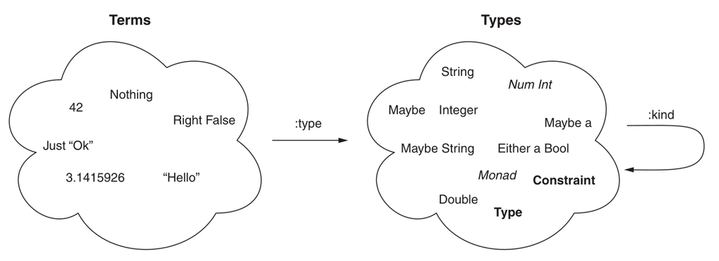

```haskell
ghci> :kind Type
Type :: Type
```

## Реализация параметрического полиморфизма

## Одна функция — четыре способа её скомпилировать

Конвенция вызова: где лежит аргумент — регистр, стек, куча — и какого он размера. Она зависит от типа, а тип `T` неизвестен.

id(42)

id(3.14)

id(user)

fun <T> id(x: T): T

Int: 4 байта?

Double: 8 байт, другой регистр?

User: указатель?

## Одна функция — четыре способа её скомпилировать

**Мономорфизация** (C++, Rust): копия кода на каждый набор типов. Самый быстрый код; долгая компиляция, большой бинарник, нет полиморфных методов в интерфейсах.

id(42)

id(3.14)

id(user)

id_Int(x: Int)

id_Double(x: Double)

id_User(x: User)

## Одна функция — четыре способа её скомпилировать

**Стирание типа** (JVM, Haskell): значения — в кучу, код один и ждёт указатели. Быстрая компиляция и гибкость; платим боксингом и индирекциями.

куча

id(42)

id(3.14)

id(user)

42

3.14

User

id(x: ptr)

## Одна функция — четыре способа её скомпилировать

**Гибрид** (C#): для ссылочных типов один код с указателями, для value-типов специализации появляются лениво, в рантайме.

куча

id(42)

id(3.14)

id(user)

User

id_Int — в рантайме

id_Double — в рантайме

id(x: ptr)

## Одна функция — четыре способа её скомпилировать

**Таблица свойств типа** (Swift): код один, а размер и способ копирования приходят вместе с типом — в таблице. Платим вызовами через таблицу.

id(42)

id(3.14)

id(user)

Int: size 8, copy

Double: size 8, copy

User: size 8, retain

id(x, vwt)

## Цена каждого подхода

|  | мономорфизация | стирание | гибрид | таблица свойств |
| --- | --- | --- | --- | --- |
| языки | C++, Rust | JVM, Haskell | C# | Swift |
| скорость кода | + лучшая | − боксинг | + value-типы | − вызовы через таблицу |
| время компиляции, размер | − | + | + | + |
| динамическая загрузка | − | + | + | + |
| полиморфные методы, higher-rank | − | + | + | + |
| тип известен в рантайме | − только статически | − стёрт | + | + |

## Таблица свойств типа в Swift

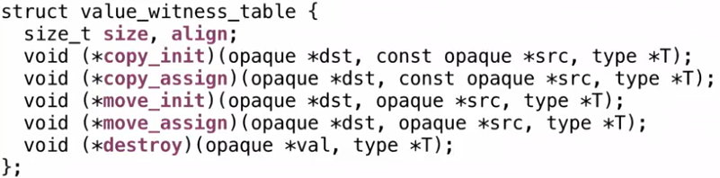

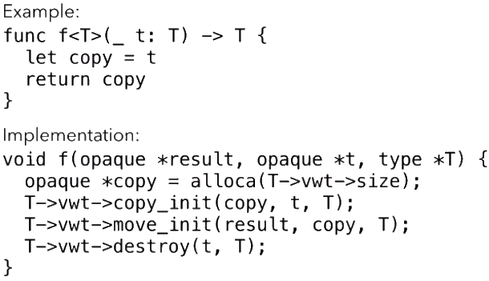

## Задачи: подходы в языках

В Kotlin (JVM, стирание типов) проверка `x is T` для типового параметра `T` разрешена только внутри `inline`-функций, где параметр помечен `reified`. Объясните ограничение. Какой из подходов здесь локально применяется?

В Rust (мономорфизация) трейт с обобщённым методом нельзя использовать как trait object (`dyn Trait`). Каким недостатком мономорфизации это объясняется?

- Kotlin: в рантайме `T` стёрт; `inline` вставляет тело в место вызова, где `T` известен, — локальная мономорфизация
- Rust: через vtable в месте вызова неизвестно, какую специализацию метода вызывать — «в интерфейсах не может быть полиморфных методов»

## Задача: плагин

Приложение подгружает плагин, скомпилированный отдельно, и хочет вызвать из него обобщённую функцию с типом, о котором автор плагина не знал. Для каждого из четырёх подходов определите, возможно ли это, и почему.

- Мономорфизация — нет: кода до специализации не существует, линковаться не к чему
- Стирание — да: один код на все типы, плагин ждёт указатели
- Гибрид — да: для reference-типов готовая специализация, для value-типов рантайм породит её при вызове
- Witness table — да: таблицу свойств типа передаст вызывающий

## Полиморфизм по конвенции вызова

## Где лежит значение

`x :: Int` — boxed: в переменной указатель, само число в куче. Обычный `Int` — это `data Int = I# Int#`.

регистры и стек

куча

x :: Int

•

I# │ 42

## Где лежит значение

И lifted: по указателю может лежать отложенное вычисление, ещё не число.

регистры и стек

куча

x :: Int

y :: Int

•

I# │ 42

•

thunk: 1 + 41

## Где лежит значение

Когда значение понадобится, вычисление заменится результатом. За лень и единообразие платим индирекцией и аллокацией.

регистры и стек

куча

x :: Int

y :: Int

•

I# │ 42

•

I# │ 42

## Где лежит значение

`z :: Int#` — unboxed и unlifted: число прямо в регистре, без кучи и без лени.

регистры и стек

куча

x :: Int

y :: Int

z :: Int#

•

I# │ 42

•

I# │ 42

42

## Две оси: boxed и lifted

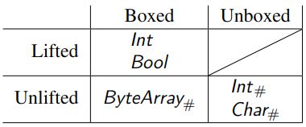

- **Boxed** — по указателю, в куче; **unboxed** — по значению
- **Lifted** — содержит $\bot$, может быть отложенным; **unlifted** — всегда вычислен
- Свойство lifted/unlifted — **levity**

```haskell
divMod# :: Int -> Int -> (# Int, Int #)       -- unboxed кортеж: два результата в двух регистрах
case divMod# n k of (# quot, rem #) -> ...
```

## Представление — в кайнде

```haskell
TYPE :: RuntimeRep -> Type

data Levity = Lifted | Unlifted

data RuntimeRep = BoxedRep Levity
                | IntRep | DoubleRep
                | TupleRep [RuntimeRep]
                | SumRep [RuntimeRep]
                | ...

type LiftedRep = BoxedRep Lifted

type Type = TYPE LiftedRep
```

## Какой кайнд?

- `Int ::` `TYPE (BoxedRep Lifted)`, или просто `Type`
- `Int# ::` `TYPE IntRep`
- `Maybe Int ::` `Type`
- `Maybe ::` `Type -> Type`
- `(# Int, Bool #) ::` `TYPE (TupleRep '[LiftedRep, LiftedRep])`
- `(# Int#, (# Int, Double# #) #) ::` `TYPE (TupleRep '[IntRep, TupleRep '[LiftedRep, DoubleRep]])`

Какой кайнд у типа `(# Int#, Bool #)`? Проверьте себя в GHCi, включив расширения MagicHash и UnboxedTuples.

`(# Int#, Bool #) :: TYPE (TupleRep '[IntRep, LiftedRep])`

## Representation polymorphism

```haskell
ghci> :k (->)
(->) :: forall {q :: RuntimeRep} {r :: RuntimeRep}. TYPE q -> TYPE r -> Type
```

Подумайте, почему функция имеет boxed тип. Может ли быть иначе? Может ли это быть полезным?

## Связыватель без представления

```haskell
bad :: forall r (a :: TYPE r). a -> a
bad x = x                      -- куда смотреть за x: регистр? какой? куча?

error: The binder ‘x’ does not have a fixed runtime representation
```

```haskell
($) :: forall ra rb (a :: TYPE ra) (b :: TYPE rb). (a -> b) -> a -> b
($) f = f                      -- связывателя нет — нет и вопроса
```

## Задача: `error`

Функция `error` полиморфна по представлению результата: `error :: forall (r :: RuntimeRep) (a :: TYPE r). String -> a`. Почему это не нарушает ограничение на связыватели?

`a` стоит только в **результате**: ни один параметр `error` не имеет тип `a`, связывателя полиморфного представления нет. А результат никогда не строится — функция бросает исключение, так что и код под произвольное представление генерировать не нужно.

## Что мы узнали

| System F | скрытый аргумент — тип; $\Lambda$ и универсальная аппликация, $TLam$/$TApp$; в Haskell — `@` |
| --- | --- |
| кайнды | λ-исчисление на уровне типов, $KLam$/$KApp$; три этажа: терм — тип — кайнд, и `Type :: Type` |
| формы полиморфизма | высшие ранги и импредикативность (first-class), higher-kinded, GADT, продвижение данных, полиморфные кайнды |
| реализация | мономорфизация, стирание, гибрид, witness table — у каждого своя цена; словари вернутся в главе 3 |
| представления | boxed/unboxed, lifted/unlifted, `TYPE r`; связыватели не бывают полиморфны по представлению |

- **Домашка fp2-02**: вектор с длиной в типе и типизированный `Expr`; формулы на уровне типов, `hzip`, `Tagged`, числа и пара Чёрча; тип `error`
- **На следующем занятии**: ad-hoc полиморфизм — классы типов как словари, резолв инстансов, семейства типов — глава 3

## Материалы

## Факультативно: эмуляция типовых аппликаций через `Proxy`

```haskell
data Proxy a = Proxy                          -- фантомный параметр: тип без значения

id :: Proxy a -> a -> a

ghci> :t id (Proxy :: Proxy Int)
id (Proxy :: Proxy Int) :: Int -> Int

id (Proxy :: Proxy a) x = (x :: a)            -- ScopedTypeVariables: сигнатура в паттерне
```

```haskell
id :: proxy a -> a -> a                       -- прокси-тип оставлен полиморфным
id (_ :: proxy a) x = (x :: a)
```

## Что почитать

- Конспект курса, глава 2 «Параметрический полиморфизм»
- Benjamin Pierce, «Types and Programming Languages», главы 23 (System F) и 29 (кайнды) — must-read по первой секции
- Brent Yorgey et al., [Giving Haskell a Promotion](https://dl.acm.org/doi/10.1145/2103786.2103795) (2012) — откуда взялись DataKinds
- Richard Eisenberg, Simon Peyton Jones, [Levity Polymorphism](https://dl.acm.org/doi/10.1145/3062341.3062357) (2017) — вся третья секция в одной статье
- Alejandro Serrano et al., [A Quick Look at Impredicativity](https://dl.acm.org/doi/10.1145/3408971) (2020) — как GHC 9.2 выводит импредикативные типы
- John Launchbury, Simon Peyton Jones, [Lazy Functional State Threads](https://dl.acm.org/doi/10.1145/178243.178246) (1994) — ST-trick
- [Implementing Swift Generics](https://youtu.be/ctS8FzqcRug) (LLVM Developers’ Meeting, 2017) — witness tables из первых рук
- Олег Киселёв, [Boehm–Berarducci encoding](https://okmij.org/ftp/tagless-final/course/Boehm-Berarducci.html) — типы высшего ранга и кодирование данных функциями